# Starling Detector Notes

Vlad Obo

10/6/2018

```r
source("birdsLib.R")
```

## Problem Description

- We have massive sound records and need to find if there are starling calls
- There are a data set of starling calls 1000+ records
- We think the data in hands reasonably cover the real conditions
- we develop specific application for starlings
- we consider mel frequency cepstrum coeffisients as a feature and HTK and KERAS as ML tools

## Parts

### Choosing MFCC parameters

After playing the data the following numbers were chosen as MFCC’s parameters.

Happy to explaine the choice.

```r
hopt
```

```
## [1] 0.025
```

```r
wint
```

```
## [1] 0.075
```

```r
getMel
```

```
## function (x)
## {
##     require(tuneR)
##     tmp <- melfcc(x, minfreq = 3000, maxfreq = 10000, fbtype = "mel",
##         numcep = 12, hopt = hopt, wint = wint)
##     return(tmp)
## }
```

### Bird call detector

- Simple detector to cut birds calls from lengthy sound records would be good to have
- I called it “MFCC power”
- The function is as below

```r
getMCPow
```

```
## function (x, excl = 1)
## {
##     colSums(t(abs(x[, -(excl)])))
## }
```

- How it works. Using 15 seconds from joined starling decreasin calls as an example

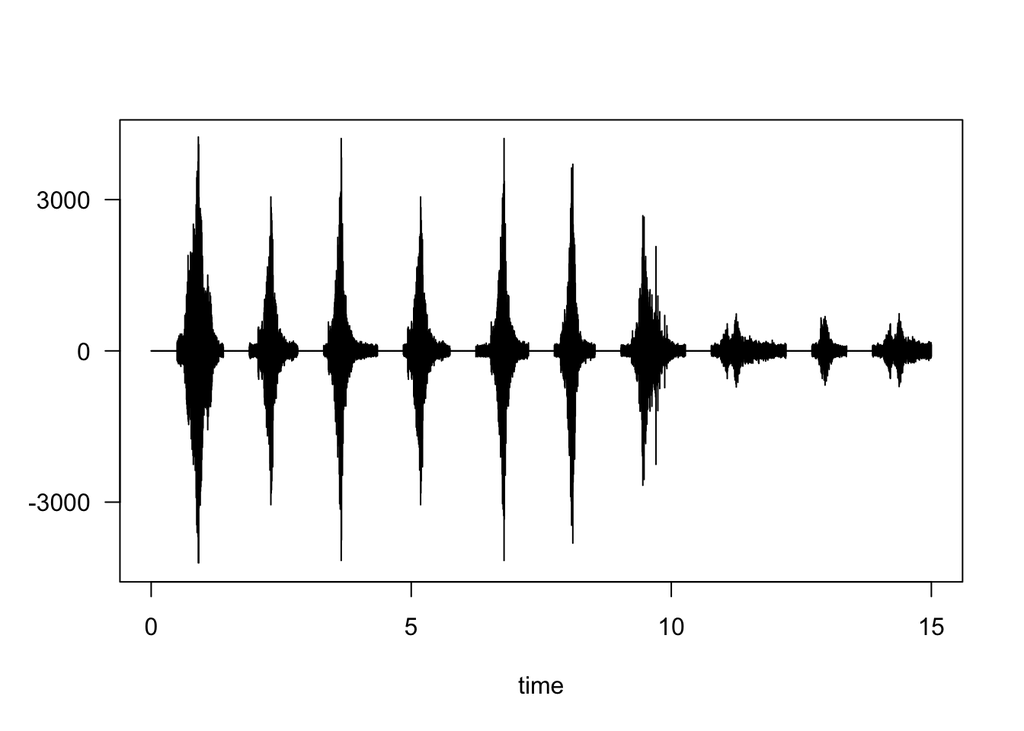

```r
sigDir="../"
fn="DecreasingCallLargeTmp.wav"
w<-readWave(paste0(sigDir, fn), from = 0, to = 15, units = "sec")

plot(w)
```

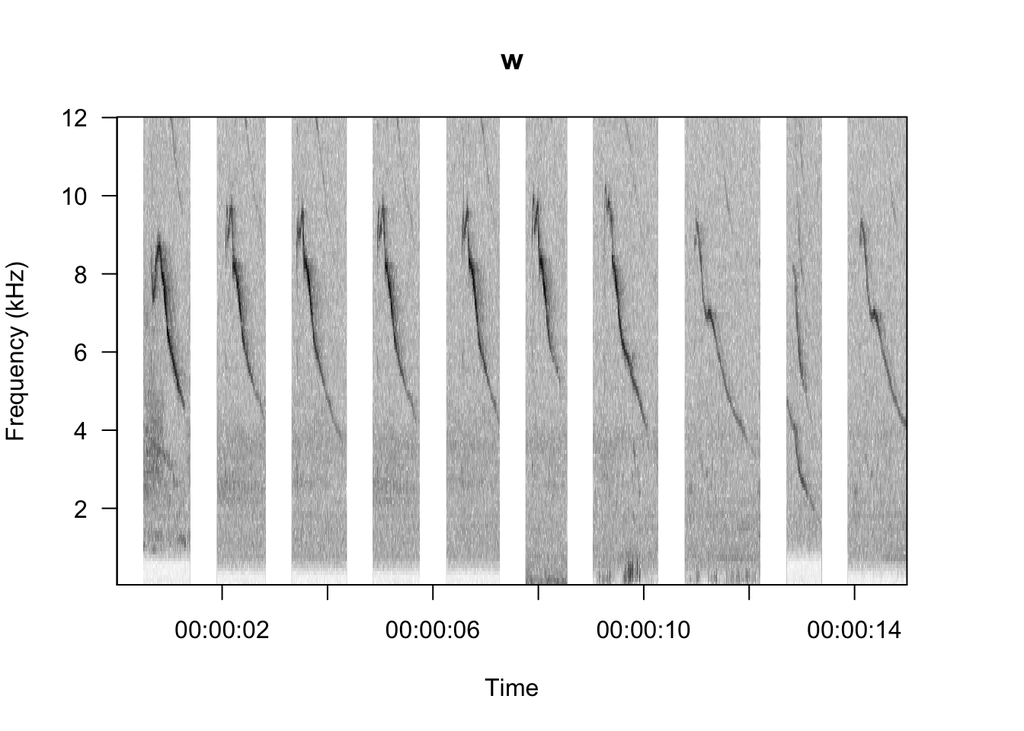

```r
viewSpec(w)
```

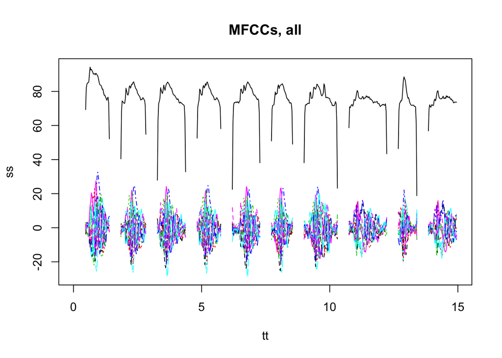

```r
ss<-getMel(w)

tt<-(1:nrow(ss)) * hopt
matplot(tt, ss, type="l", main="MFCCs, all")
```

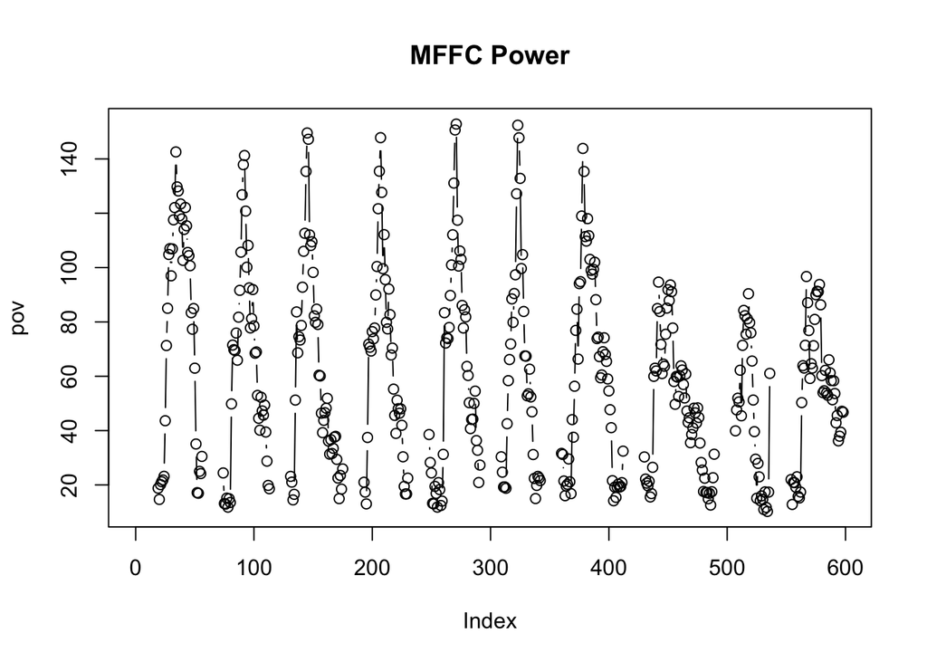

```r
pov=getMCPow(ss)
plot(pov, type="b", main="MFFC Power")
```

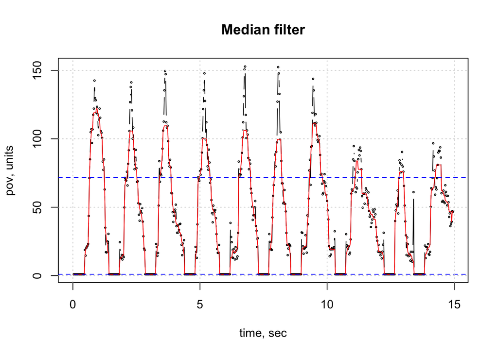

```r
showMCPow(pov)
title(main="Median filter")
```

```r
win.range<-c(0.4, 0.8)
```

- I use this file DecreasingCallLargeTmp.wav to produce the estimate for target window length
- The target window size set to 0.4, 0.8 sec

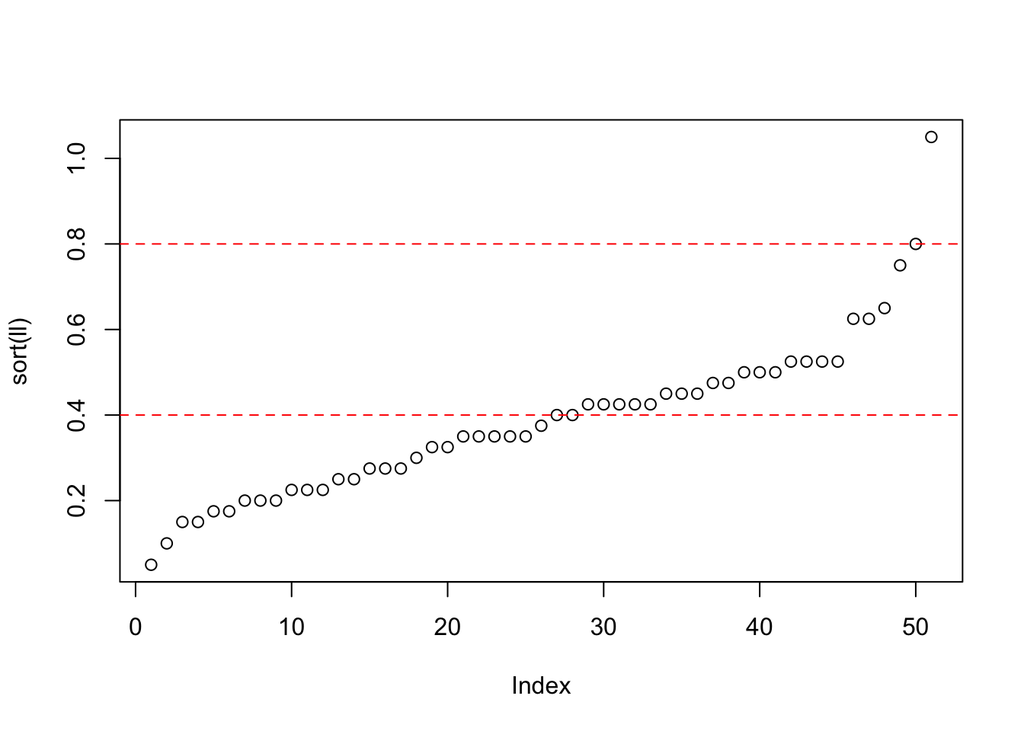

```r
wins<-readWave(paste0(sigDir, fn)) %>%
  getMel %>%
  getMCPow %>%
  getAWins

ll<-with(wins, end-start)

plot(sort(ll))
abline(h=win.range, lty=2, col="red")
```

## Real audio

- Now worrking on the file MU000_20091021_172000.wav (the first helf hour only here to avoid memory problems)
- From 0 to 30, in minutes

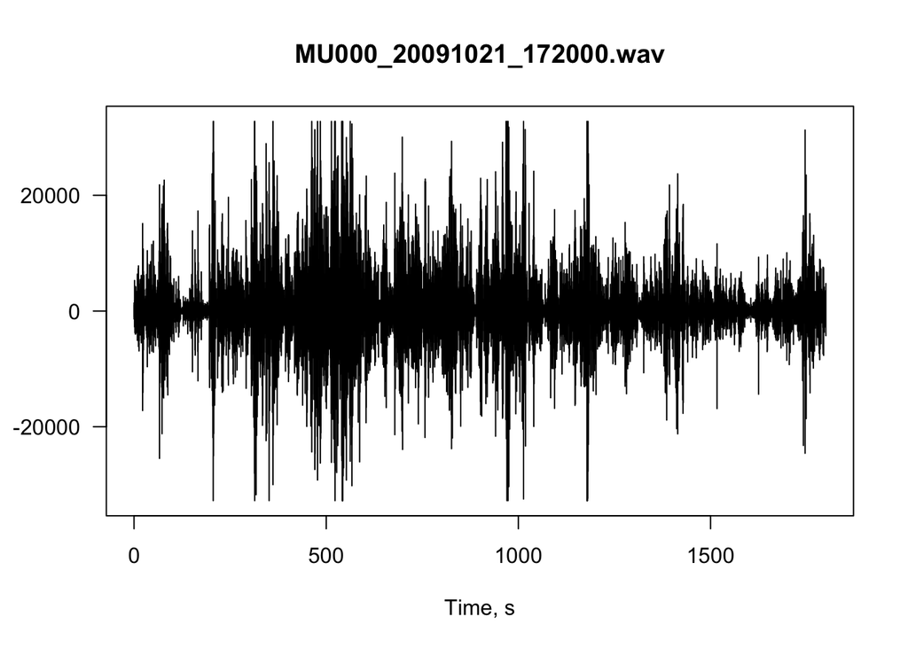

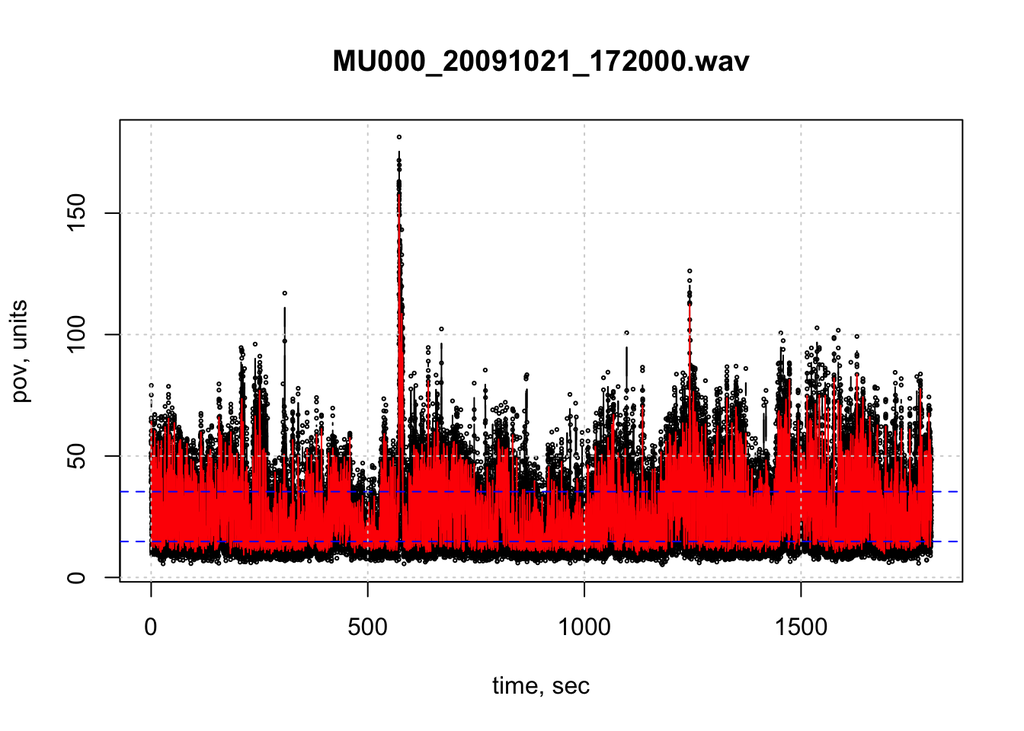

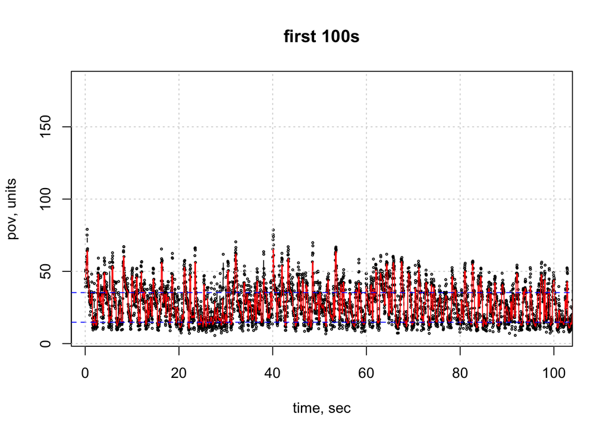

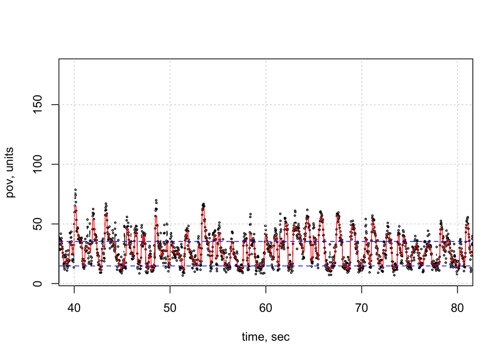

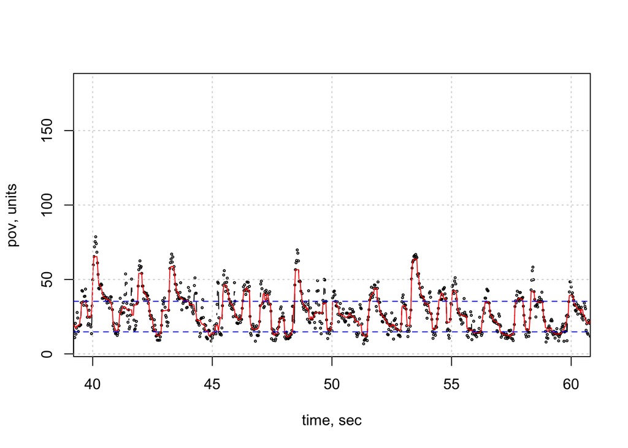

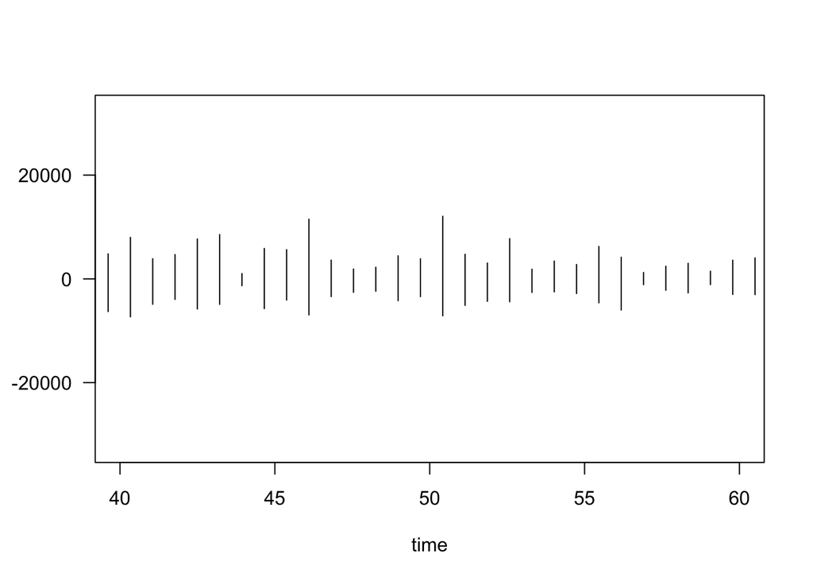

## Action windows in real audio file

- We seek time windows with enough action in them
- It means when the median filter output is greater than the threshold
- Threshold used by default (see function “getAWins”) is the top quartile of “pov”

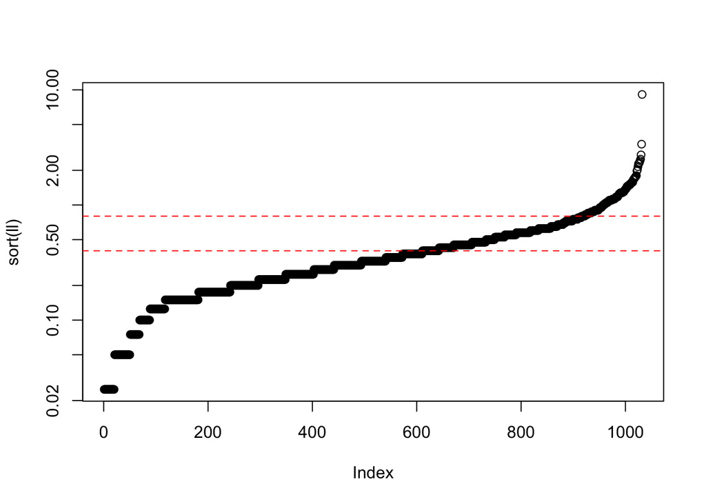

```r
## be careful -- remove the tmp file when changing the input wav
tmp.fn="action.wins.RData"
#file.remove(tmp.fn)
if (file.exists(tmp.fn)) load(tmp.fn) else {

action.wins <- (ppov<- paste0(sigDir, lfn) %>%
                  readWave(from=0, to = 30, units="min") %>%
                  mono %>%
                  getMel() %>%
                  getMCPow()
                ) %>%
  getAWins()
save(ppov, action.wins, file=tmp.fn) }

ll<-with(action.wins, end-start)

plot(sort(ll), log="y")
abline(h=win.range, col="red", lty=2)
```

```r
ii<-which(inrange(ll, win.range))
```

- Number of action windows similar to starling decr.call window size

```r
table(inrange(ll, win.range))
```

```
##
## FALSE  TRUE
##   740   292
```

```r
sum(ll[ii])
```

```
## [1] 161.875
```

- Let’s generate wav including only fragments determined by the action windows. Accomponying selection table is written too. The can be viewed by Raven

```r
ofn="wins.wav"
winsWav(infile=ifn, outfile=ofn, ww=action.wins[ii,])
```

- Selection table to be used with original file to show these selected windows

```r
writeSelectionTable(wins=action.wins, ofn="actionWins.txt")
```